## label

**1. Create one plot on the fuel economy data with customized title , subtitle , caption , x , y , and colour labels.**

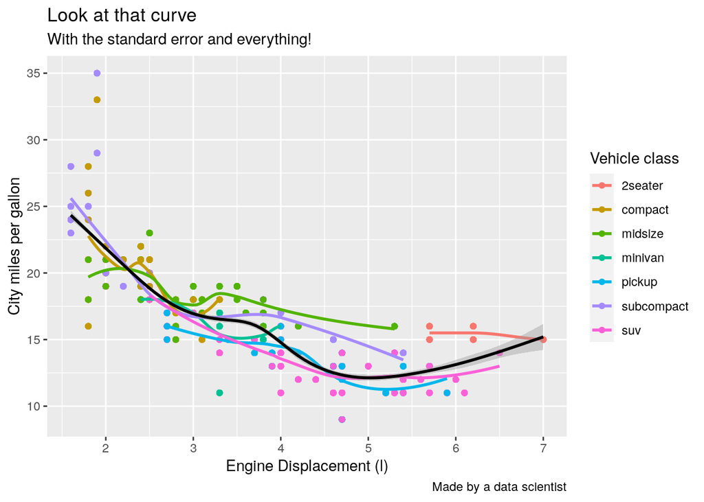

**2. The geom_smooth() is somewhat misleading because the hwy for large engines is skewed upwards due to the inclusion of light‐weight sports cars with big engines. Use your modeling tools to fit and display a better model.**

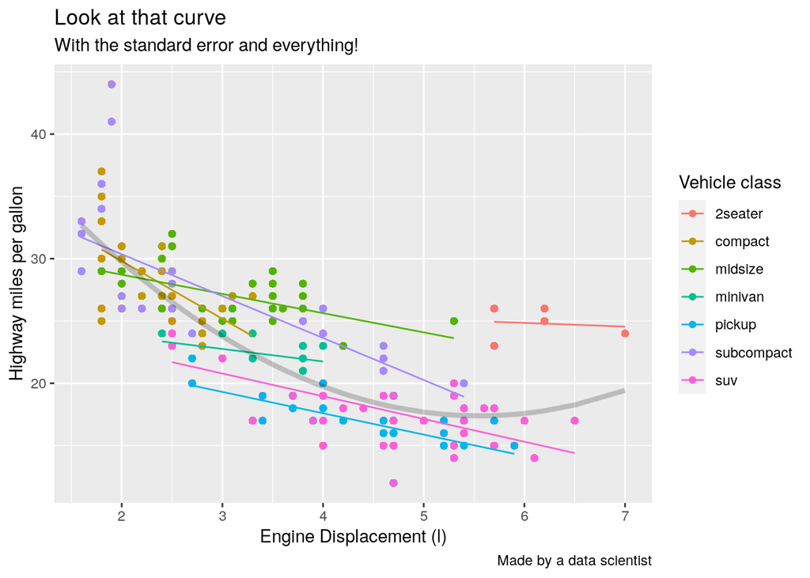

**3. Take an exploratory graphic that you’ve created in the last month, and add informative titles to make it easier for others to understand.**

## annotations

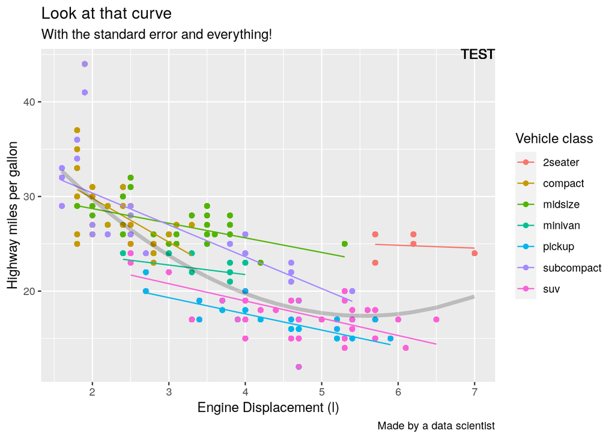

**2. Read the documentation for annotate() . How can you use it to add a text label to a plot without having to create a tibble? *ANS: just pass them in as stand along vector objects.***

**3. How do labels with geom_text() interact with faceting? How can you add a label to a single facet? How can you put a different label in each facet? (Hint: think about the underlying data.)**

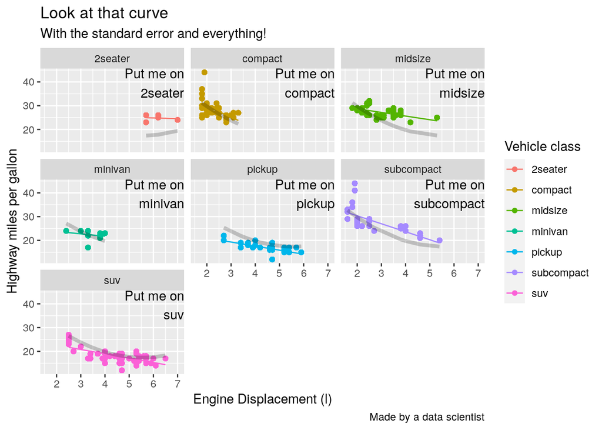

**4. What arguments to geom_label() control the appearance of the background box? *ANS: label.padding, label.r, label.size, ‘fill’ aesthetics***

**5. What are the four arguments to arrow() ? How do they work? Create a series of plots that demonstrate the most important options.**

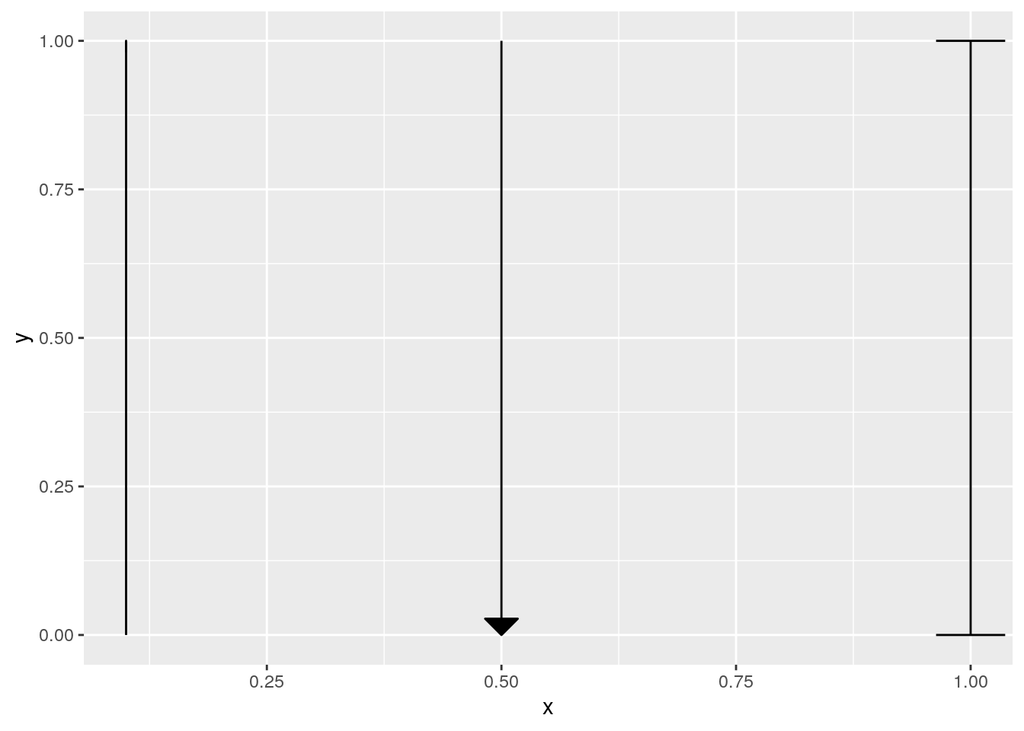